# FCOR599: Capstone

Wildfire Recovery using Landsat Imagery

Sarah Kopitz

21 February 2026

## Wildfire Recovery

### Load Packages

**Load Packages**

Set Up - install necessary packages

```r
# install packages
library(terra)         # raster processing
library(sf)            # vector spatial data
library(dplyr)
library(tidyverse)
```

### Fire Perimeter Polygon

**Fire Perimeter Polygon**

This section defines the study area by isolating specific wildfire boundaries from the National Fire Database (CWFIS). Three fire IDs: NE063, NE064, and NE065 are merged into a single polygon to represent the total area burned on June 6, 2013. This merged perimeter serves as the “Region of Interest” (ROI). To ensure the boundary aligns with Landsat pixels the polygon is reprojected to UTM Zone 14N (EPSG: 32614) and converted into a terra vector object for processing.

```r
# read in roi shapefile - contains 3 fire IDs
roi <- st_read("data/roi/roi.shp")
```

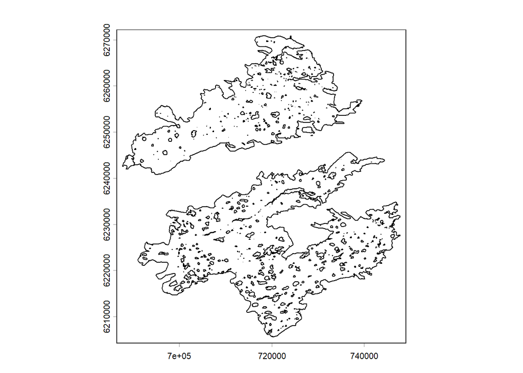

```r
# merge the 3 fire polygons into 1
roi_merged <- st_union(roi)

# match coordinate systems between aoi and landsat
# ESPG: 32614 (WGS84: UTM Zone 14N)
roi_reproject <- st_transform(roi_merged, crs=32614)

# convert from sf to terra
roi_vect <- vect(roi_reproject)

# view
plot(roi_vect)
```

### Process Landsat Scenes

**Process Landsat Scenes**

This section cleans and prepares the raw Landsat 5 and Landsat 8 surface reflectance data. For every scene a QA mask is used to pull out clouds and shadows so only clear pixels are left. Each image is clipped to the fire perimeter and reprojected to match the study area.

The code extracts the Red, NIR, and SWIR2 bands to calculate NDVI and NBR. For each scene, three separate files are saved: a multispectral SR stack containing all original bands, an NDVI raster, and an NBR raster.

**Landsat data connections**

```r
# data folder
base_dir <- "data"

# set landsat directories
l5_dir <- file.path(base_dir, "landsat5")
l8_dir <- file.path(base_dir, "landsat8")

# output data folder
out_dir <- file.path(base_dir, "processed")
```

**Landsat 5**

```r
# list folders in the landsat 5 directory
l5_folders <- list.dirs(l5_dir, full.names = TRUE, recursive = FALSE)

# loop through all landsat product folders
for (d in l5_folders) {

  # list sr bands - Landsat 5 has 6 files (B1, B2, B3, B4, B5, B7)
  sr_files <- list.files(d, pattern = "SR_B[1-7].TIF$", full.names = TRUE)

  # ensure files are ordered so B1 - B7 line up correctly
  sr_files <- sr_files[order(sr_files)]

  # read sr as multilayer raster
  sr <- rast(sr_files)

  # give bands names
  names(sr) <- c("B1", "B2", "B3", "B4", "B5", "B7")

  # reproject aoi to match landsat
  roi_vect_proj <- project(roi_vect, crs(sr))

  # read in qa_pixel and mask out everything except clear pixels
  qa_file <- list.files(d, pattern = "QA_PIXEL.TIF$", full.names = TRUE)

  # read qa raster
  qa <- rast(qa_file)

  # create a mask of clear pixels: TRUE where QA == 5440 (clear)
  clear_mask <- qa == 5440

  # apply mask: keep TRUE (clear) pixels, mask FALSE pixels
  sr_masked <- mask(sr, clear_mask, maskvalues = FALSE)

  # crop to prouton fire extent
  sr_crop <- crop(sr_masked, roi_vect_proj)

  # extract bands (Red=B3, NIR=B4, SWIR2=B7)
  red <- sr_crop[[3]]
  nir <- sr_crop[[4]]
  swir2 <- sr_crop[[6]]

  # calculate : ndvi
  ndvi <- (nir - red) / (nir + red)
  names(ndvi) <- "ndvi"

  # calculate : nbr
  nbr <- (nir - swir2) / (nir + swir2)
  names(nbr) <- "nbr"

  # write outputs: SR stack, NDVI, NBR
  writeRaster(sr_crop, file.path("data/processed/sr", paste0(basename(d),
              "_sr.tif")), overwrite = TRUE)
  writeRaster(ndvi, file.path("data/processed/ndvi", paste0(basename(d),
              "_ndvi.tif")), overwrite = TRUE)
  writeRaster(nbr, file.path("data/processed/nbr", paste0(basename(d),
              "_nbr.tif")), overwrite = TRUE)
}
```

**Landsat 8**

```r
# list folders in the landsat 8 directory'
l8_folders <- list.dirs(l8_dir, full.names = TRUE, recursive = FALSE)

# loop through all landsat product folders
for (d in l8_folders) {

   # list sr bands (B1-B7)
  sr_files <- list.files(d, pattern = "SR_B[1-7].TIF$", full.names = TRUE)

  # ensure files are ordered so B1 - B7 line up correctly
  sr_files <- sr_files[order(sr_files)]

  # read sr as multilayer raster
  sr <- rast(sr_files)

  # give bands names
  names(sr) <- paste0("B", 1:7)

  # reproject aoi to match landsat
  roi_vect_proj <- project(roi_vect, crs(sr))

  # read in qa_pixel and make out everything except clear pixels (value 21824)
  qa_file <- list.files(d, pattern = "QA_PIXEL.TIF$", full.names = TRUE)

  # read qa raster
  qa <- rast(qa_file)

  # create a mask of clear pixels: TRUE where QA == 21824 (clear)
  clear_mask <- qa == 21824

  # apply mask: keep TRUE (clear) pixels, mask FALSE pixels
  sr_masked <- mask(sr, clear_mask, maskvalues = FALSE)

  # crop to fire extent
  sr_crop <- crop(sr_masked, roi_vect_proj)

  # extract bands (Red=B4, NIR=B5, SWIR2=B7)
  red <- sr_crop[[4]]
  nir <- sr_crop[[5]]
  swir2 <- sr_crop[[7]]

  # calculate : ndvi
  ndvi <- (nir - red) / (nir + red)
  names(ndvi) <- "ndvi"

  # calculate : nbr
  nbr <- (nir - swir2) / (nir + swir2)
  names(nbr) <- "nbr"

  # write outputs: SR stack, NDVI, NBR
  writeRaster(sr_crop, file.path("data/processed/sr", paste0(basename(d),
              "_sr.tif")), overwrite = TRUE)
  writeRaster(ndvi, file.path("data/processed/ndvi", paste0(basename(d),
              "_ndvi.tif")), overwrite = TRUE)
  writeRaster(nbr, file.path("data/processed/nbr", paste0(basename(d),
              "_nbr.tif")), overwrite = TRUE)
}
```

### Yearly Composites

**Yearly Composites**

This section builds yearly NDVI and NBR composites from all the processed Landsat scenes. The code loops through each year from 2010 to 2024 and pulls every available image for that specific year. For every pixel, the median value is calculated across all images in the stack to create a single representative map for each year. These yearly maps are combined into two final multilayer stacks one for NDVI and one for NBR and saved as TIF files.

**NDVI composite**

```r
# folder containing only NDVI files
ndvi_path <- "data/processed/ndvi"

# list all files
ndvi_files <- list.files(ndvi_path, full.names = TRUE)

# extract year from filename
years <- substr(basename(ndvi_files), 18, 21)

# sort by year and pull out each unique year
unique_years <- sort(unique(years))

# list container to store the raster for each year
ndvi_yearly_list <- list()

# loop to create composite
for (yr in unique_years) {

  # find the positions of all files that belong to the current year
  target_indices <- which(years == yr)

  # ndvi files for this year using positions from above
  target_files <- ndvi_files[target_indices]

  # load them into a temporary stack
  r_year_stack <- rast(target_files)

  # calculate each pixel median
  ndvi_median <- app(r_year_stack, fun = median, na.rm = TRUE)

  # crop and mask to the fire extent - removes pixels outside
  ndvi_median <- crop(ndvi_median, roi_vect)
  ndvi_median <- mask(ndvi_median, roi_vect)

  # rename the layer - "NDVI_2013", ... etc.
  names(ndvi_median) <- paste0("NDVI_", yr)

  # store in list
  ndvi_yearly_list[[yr]] <- ndvi_median
}

# Combine the list of yearly maps into one SpatRaster object
ndvi_comp <- rast(ndvi_yearly_list)

# name stack layers
names(ndvi_comp) <- paste0("NDVI_", unique_years)

# verify output
print(ndvi_comp)
```

```
## class       : SpatRaster
## size        : 2177, 2004, 14  (nrow, ncol, nlyr)
## resolution  : 30, 30  (x, y)
## extent      : 687645, 747765, 6205605, 6270915  (xmin, xmax, ymin, ymax)
## coord. ref. : WGS 84 / UTM zone 14N (EPSG:32614)
## source(s)   : memory
## names       :  NDVI_2010,   NDVI_2011,  NDVI_2013,   NDVI_2014,  NDVI_2015,  NDVI_2016, ...
## min values  : -0.1169253, -0.02423507, -0.0777167, -0.07600419, -0.1064937, -0.0784556, ...
## max values  :  0.4168504,  0.58640295,  0.6404078,  0.41602254,  0.4321031,  0.4502250, ...
```

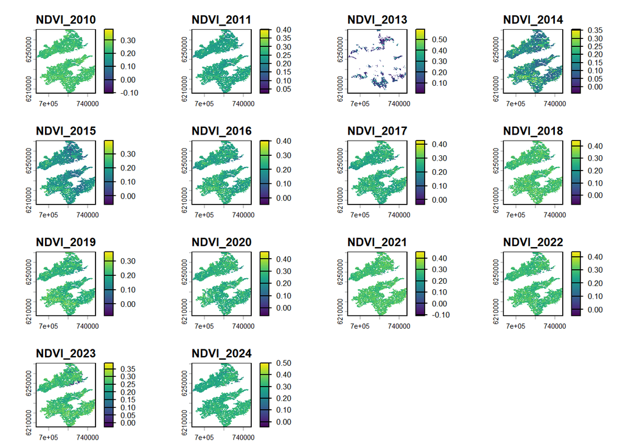

```r
plot(ndvi_comp)
```

```r
# save this stack
writeRaster(ndvi_comp, "output/NDVI_Stack_2010_2024.tif",
            overwrite = TRUE)
```

**NBR composite**

```r
# folder containing NBR files
nbr_path <- "data/processed/nbr"

# List all files
nbr_files <- list.files(nbr_path, full.names = TRUE)

# extract year from filename
years <- substr(basename(nbr_files), 18, 21)

# sort by year and pull out each unique year
unique_years <- sort(unique(years))

#list to store the raster for each year
nbr_yearly_list <- list()

# loop to create composite - for each year
for (yr in unique_years) {

  # find the positions of all files that belong to the current year
  target_indices <- which(years == yr)

  # nbr files for this year using positions from above
  target_files <- nbr_files[target_indices]

  # load them into a temporary stack
  r_year_stack <- rast(target_files)

  # Calculate each pixel median
  nbr_median <- app(r_year_stack, fun = median, na.rm = TRUE)

  # crop and mask to the fire extent - removes pixels outside
  nbr_median <- crop(nbr_median, roi_vect)
  nbr_median <- mask(nbr_median, roi_vect)

  # rename the layer
  names(nbr_median) <- paste0("NBR_", yr)

  # store in list
  nbr_yearly_list[[yr]] <- nbr_median
}

# Combine into final stack
nbr_comp <- rast(nbr_yearly_list)
names(nbr_comp) <- paste0("NBR_", unique_years) # name stack layers

# verify output
print(nbr_comp)
```

```
## class       : SpatRaster
## size        : 2177, 2004, 14  (nrow, ncol, nlyr)
## resolution  : 30, 30  (x, y)
## extent      : 687645, 747765, 6205605, 6270915  (xmin, xmax, ymin, ymax)
## coord. ref. : WGS 84 / UTM zone 14N (EPSG:32614)
## source(s)   : memory
## names       :    NBR_2010,    NBR_2011,   NBR_2013,   NBR_2014,   NBR_2015,   NBR_2016, ...
## min values  : -0.08410207, -0.07673569, -0.7048772, -0.2208154, -0.2033041, -0.1646364, ...
## max values  :  0.40306851,  0.62730736,  0.4270480,  0.4049724,  0.4074681,  0.4372463, ...
```

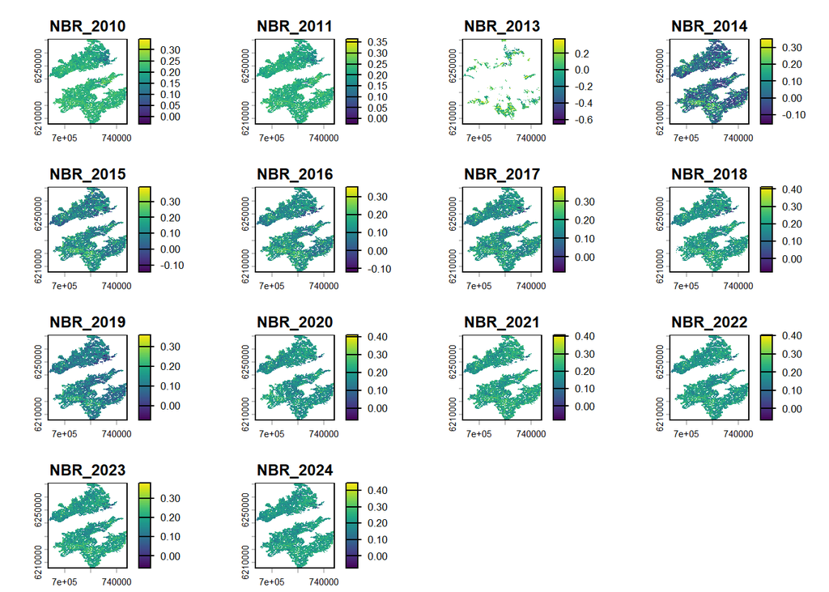

```r
plot(nbr_comp)
```

```r
# save this stack
writeRaster(nbr_comp, "output/NBR_Stack_2010_2024.tif",
            overwrite = TRUE)
```

### Burn Severity

**Burn Severity**

This section calculates the differenced Normalized Burn Ratio (dNBR). A pre-fire year (2011) and a post-fire year (2014) are used to generate a continuous dNBR surface. The output is saved as a raster for mapping and converted to a dataframe for later joins and summaries.

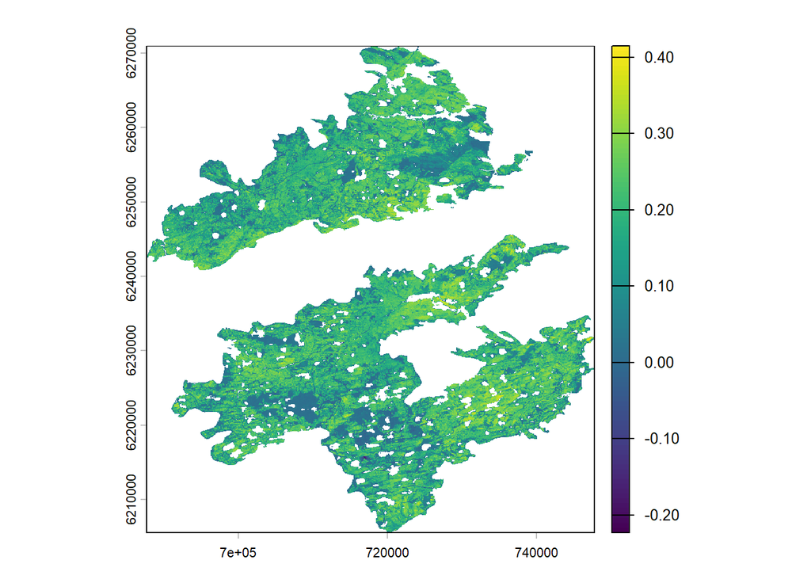

```r
# extract Pre-Fire (2011) and Post-Fire (2014)
pre_fire  <- nbr_comp[["NBR_2011"]]
post_fire <- nbr_comp[["NBR_2014"]]

# calculate dNBR
dnbr_raw <- pre_fire - post_fire

# save to tiff
writeRaster(dnbr_raw, "output/dNBR_Raw.tif", overwrite = TRUE)

# create data frame
severity_df <- as.data.frame(dnbr_raw, xy = TRUE, na.rm = TRUE)

# rename the third column
colnames(severity_df)[3] <- "dNBR_raw"

# view
plot(dnbr_raw)
```

### Baseline: Pre Fire Averages

**Baseline - Pre Fire Averages**

This section establishes the pre-fire “normal” for the study area by calculating the average spectral values before the disturbance occurred. Using data from 2010 and 2011, the code calculates the mean for every pixel inside the fire perimeter .

Two separate baseline layers are generated: one for NDVI and one for NBR. These layers are the “targets” used later in the Year to Recovery (Y2R) calculation, where recovery is defined as a pixel returning to 80% of these original pre-fire values .

**NDVI Baseline**

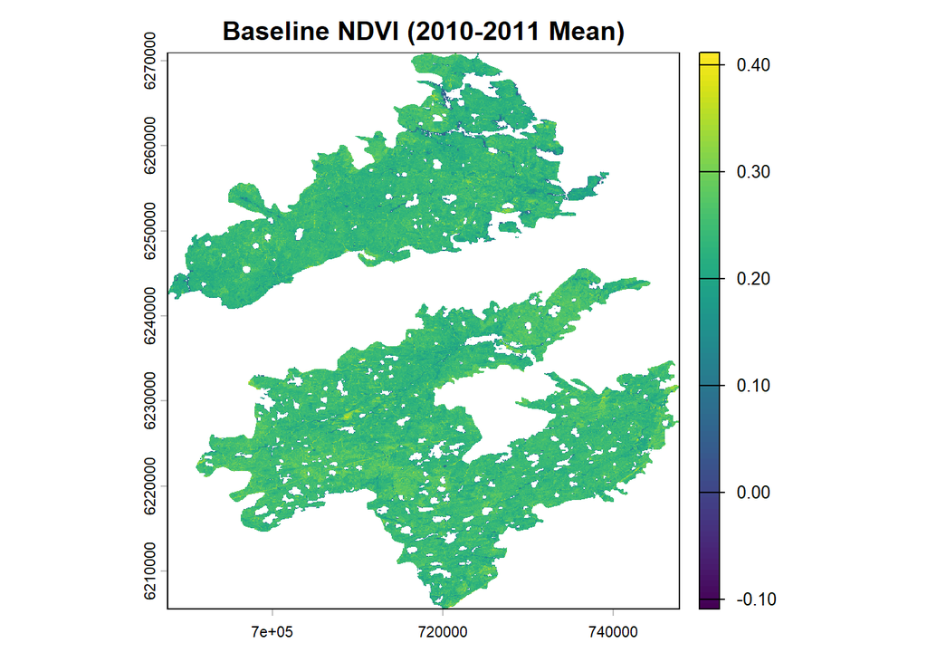

```r
# select pre fire years (2010 & 2011)
ndvi_pre_fire <- c("NDVI_2010", "NDVI_2011")

# calculate baseline - mean of 2010 & 2011
ndvi_baseline <- app(ndvi_comp[[ndvi_pre_fire]], fun = mean, na.rm = TRUE)
names(ndvi_baseline) <- "Baseline_NDVI_2010_2011"

# view - plot
plot(ndvi_baseline, main = "Baseline NDVI (2010-2011 Mean)")
```

**NBR Baseline**

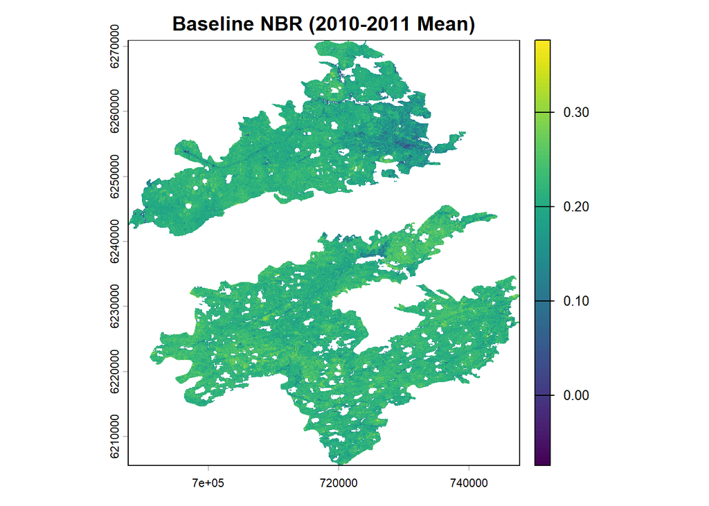

```r
# select pre fire years (2010 & 2011)
nbr_pre_fire <- c("NBR_2010", "NBR_2011")

# calculate baseline - mean of 2010 & 2011
nbr_baseline <- app(nbr_comp[[nbr_pre_fire]], fun = mean, na.rm = TRUE)
names(nbr_baseline) <- "Baseline_NBR_2010_2011"

# view - plot
plot(nbr_baseline, main = "Baseline NBR (2010-2011 Mean)")
```

### Recovery: Pixel Based Recovery Slopes

**Recovery: Pixel Based Recovery Slopes**

This section focuses on calculating the rate of vegetation regrowth for every pixel within the fire perimeter. The analysis uses a linear regression model to look at yearly index values from 2014 to 2023 (2014 is used as its first year after fire).

A custom function *calc_slope* is applied to the time series stack to extract the slope (m), which represents the recovery rate. A positive slope indicates that vegetation is re-establishing, while a negative or near-zero slope suggests limited recovery. In addition to the slope, the code calculates the p-value to test for statistical significance and the R-squared to measure how well the linear trend fits the yearly observations. This calculation is performed for both NDVI and NBR.

**Slope Equation - Function**

```r
# linear regression function
calc_slope <- function(y) {

   # if there are only 1 or 2 points, return NA
  if (sum(!is.na(y)) < 3) {
    return(c(NA, NA, NA))
  }

  # run linear regression (y ~ x)
  model <- lm(y ~ time_vec, na.action = na.omit)
  mod_sum <- summary(model)

  # extract slope, R squared, and p-value
  slope <- coef(model)[2]
  r2 <- mod_sum$r.squared
  p_val <- mod_sum$coefficients[2, 4]

  # return
  return(c(slope, r2, p_val))
}
```

**NDVI - Calculate Recovery Slope (2014-2023)**

```r
# define recovery period - annual values for 2014-2023
recovery_years <- 2014:2023

# create vector of NDVI names
layer_names <- paste0("NDVI_", recovery_years)

# Subset the NDVI stack
recovery_stack_ndvi <- ndvi_comp[[layer_names]]

# create a time vector: 1, 2, ... 10 (for the 10 years)
time_vec <- 1:nlyr(recovery_stack_ndvi)

# run calculation on every pixel- linear regression model
ndvi_stats <- app(recovery_stack_ndvi, fun = calc_slope)

# rename 3 fields calculated from linear regression model
names(ndvi_stats) <- c("NDVI_Slope", "NDVI_R2", "NDVI_P")

# save the results as a TIF
writeRaster(ndvi_stats, "output/NDVI_Recovery_Stats.tif", overwrite = TRUE)
```

**NBR - Calculate Recovery Slope (2014-2023)**

```r
# define recovery period - annual values for 2014-2023
recovery_years <- 2014:2023

# create vector of NBR names
layer_names_nbr <- paste0("NBR_", recovery_years)

# Subset the NBR stack
recovery_stack_nbr <- nbr_comp[[layer_names_nbr]]

# Create a time vector: 1 to 10 (for the 10 years)
time_vec <- 1:nlyr(recovery_stack_nbr)

# run calculation on every pixel - linear regression model
nbr_stats <- app(recovery_stack_nbr, fun = calc_slope)

# rename 3 fields calculated from linear regression model
names(nbr_stats) <- c("NBR_Slope", "NBR_R2", "NBR_P")

# save the results as a TIF
writeRaster(nbr_stats, "output/NBR_Recovery_Stats.tif", overwrite = TRUE)
```

### Recovery: Year to Recovery (Y2R)

**Recovery: Year to Recovery (Y2R)**

This section calculates Year-to-Recovery (Y2R). For each pixel recovery is defined as the first year in which the vegetation index reaches at least 80% of its pre-fire baseline for two consecutive years.

**NDVI Y2R calculation**

```r
# target ndvi per pixel - define: recovery threshold = 80% baseline
target_ndvi <- ndvi_baseline * 0.80

# Subset to post-fire years only (2014–2024)
recovery_stack_ndvi <- ndvi_comp[[paste0("NDVI_", 2014:2024)]]

# create empty raster matching NDVI stack
ndvi_y2r_map <- rast(recovery_stack_ndvi[[1]], vals = 0)

# loop to check for two consecutive years above the target
for (i in 1:(nlyr(recovery_stack_ndvi) - 1)) {

  # Check if year 'i' and year 'i+1' are both grater than target
  is_recovered <- (recovery_stack_ndvi[[i]] >= target_ndvi) &
                  (recovery_stack_ndvi[[i+1]] >= target_ndvi)

  # Only assign the year if the pixel is currently NA (not already assigned)
  current_val <- 2013 + i
  ndvi_y2r_map <- ifel(is_recovered & ndvi_y2r_map == 0, current_val, ndvi_y2r_map)
}

# mask to fire perimeter
ndvi_y2r_map <- mask(ndvi_y2r_map, roi_vect)

# rename field
names(ndvi_y2r_map) <- "NDVI_recovery_year"

# save this stack
writeRaster(ndvi_y2r_map, "output/NDVI_Y2R_map.tif", overwrite = TRUE)

# table
ndvi_Y2R_tbl <- freq(ndvi_y2r_map)
ndvi_Y2R_tbl
```

```
##    layer value  count
## 1      1     0  24665
## 2      1  2014 369326
## 3      1  2015 192491
## 4      1  2016 799919
## 5      1  2017 254239
## 6      1  2018   4286
## 7      1  2019   3971
## 8      1  2020  13134
## 9      1  2021   2831
## 10     1  2022   1145
## 11     1  2023   3118
```

**NBR Y2R calculation**

```r
# target nbr per pixel - define: recovery threshold = 80% baseline
target_nbr <- nbr_baseline * 0.8

# Subset to post-fire years only (2014–2024)
recovery_stack_nbr <- nbr_comp[[paste0("NBR_", 2014:2024)]]

# create empty raster matching NBR stack
nbr_y2r_map <- rast(recovery_stack_nbr[[1]], vals = 0)

# loop to check for two consecutive years above the target
for (i in 1:(nlyr(recovery_stack_nbr) - 1)) {

  # Check if year 'i' and year 'i+1' are both grater than target
  is_recovered_nbr <- (recovery_stack_nbr[[i]] >= target_nbr) &
                    (recovery_stack_nbr[[i+1]] >= target_nbr)

  # Only assign the year if the pixel is currently NA (not already assigned)
  current_val_nbr <- 2013 + i
  nbr_y2r_map <- ifel(is_recovered_nbr & nbr_y2r_map == 0, current_val_nbr, nbr_y2r_map)
}

# mask to fire perimeter
nbr_y2r_map <- mask(nbr_y2r_map, roi_vect)

# rename the field
names(nbr_y2r_map) <- "NBR_recovery_year"

# save this stack
writeRaster(nbr_y2r_map, "output/NBR_Y2R_map.tif", overwrite = TRUE)

# table
nbr_Y2R_tbl <- freq(nbr_y2r_map)
nbr_Y2R_tbl
```

```
##    layer value  count
## 1      1     0 486197
## 2      1  2014 255578
## 3      1  2015 134960
## 4      1  2016  48509
## 5      1  2017 234237
## 6      1  2018   5155
## 7      1  2019   1580
## 8      1  2020 294856
## 9      1  2021 143222
## 10     1  2022  21306
## 11     1  2023  43525
```

### NTEMS Land Cover

**NTEMS Land Cover**

This section creates an NTEMS land cover stack. Land cover rasters are loaded, ordered by year, reprojected using nearest-neighbour, masked to the ROI, and saved as a raster stack. 2012 (prefire) is pulled out as a focused for further analysis.

**Create NTEMS Land Cover Stack**

```r
# land cover layer folder
lc_dir <- file.path("data", "land_cover_layers")

# list all tif files within the folders
lc_tifs <- list.files(lc_dir, "\\.tif$", full.names = TRUE, recursive = TRUE)

# pull year from file names
lc_years <- as.integer(str_extract(basename(lc_tifs), "\\d{4}"))

# order files by year
lc_tifs <- lc_tifs[order(lc_years)]

# sort year vector
lc_years <- sort(lc_years)

# list for yearly rasters
lc_list <- list()

# loop through yearly rasters
for (i in seq_along(lc_tifs)) {

  # load raster
  r <- rast(lc_tifs[i])

  # reproject - using 'near' to preserve category IDs
  r_proj <- project(r, ndvi_comp, method = "near")

  # crop and mask to ROI
  r_roi <- mask(crop(r_proj, roi_vect), roi_vect)

  # store raster with year name
  lc_list[[paste0("LC_", lc_years[i])]] <- r_roi
}

# build stack from list
lc_stack <- rast(lc_list)

# save stack to file
writeRaster(lc_stack, "output/LC_stack_2011_2022.tif", overwrite = TRUE)
```

**2012 (pre fire) NTEMS land Cover Focus**

```r
# load the processed land cover stack
lc_stack <- rast("output/LC_stack_2011_2022.tif")

# get 2012 land cover layers
lc_2012 <- lc_stack[["LC_2012"]]

# convert to data frame
lc_df <- as.data.frame(lc_2012, xy = TRUE, na.rm = TRUE)

# rename land cover ID column
colnames(lc_df)[3] <- "land_cover_ID"

# define land cover lookup table
land_cover_lookup <- data.frame(
  land_cover_ID = c(0, 20, 31, 32, 33, 40, 50, 80, 81, 100, 210, 220, 230),
  LC_Name = c("Unclassified", "Water", "Snow/Ice", "Rock/Rubble",
              "Exposed/Barren", "Bryoids", "Shrubs", "Wetland",
              "Wetland-Treed", "Herbs", "Coniferous", "Broadleaf", "Mixedwood"))

# join land cover names onto lc_df
lc_df <- lc_df %>%
  left_join(land_cover_lookup, by = "land_cover_ID")
```

### Tables

**Tables**

This section creates pixel level tables for analysis. NDVI, NBR, dNBR, and land cover rasters are converted to data frames (with x/y coordinates) and merged into one combined table.

**NDVI**

```r
# Combine: Baseline (10-11) + Recovery (14-23) + Stats (slope/R2/p) + Y2R
full_ndvi_stack <- c(ndvi_baseline, recovery_stack_ndvi, ndvi_stats, ndvi_y2r_map)

# Convert to table
ndvi_table <- as.data.frame(full_ndvi_stack, xy = TRUE, na.rm = FALSE)
```

**NBR**

```r
# Combine: Baseline (10-11) + Recovery (14-23) + Stats (slope/R2/p) + Y2R
full_nbr_stack <- c(nbr_baseline, recovery_stack_nbr, nbr_stats, nbr_y2r_map)

# Convert to table
nbr_table <- as.data.frame(full_nbr_stack, xy = TRUE, na.rm = FALSE)
```

**Combined - NDVI & NBR & Severity & 2012 Land Cover**

```r
# combine NDVI & NBR tables - join them based on the X and Y coordinates
combined_table <- merge(ndvi_table, nbr_table, by = c("x", "y"), all = TRUE)

# merge burn severity data
combined_table <- merge(severity_df, combined_table, by = c("x", "y"), all.x = TRUE)

# join 2012 land cover
combined_table <- merge(combined_table, lc_df, by = c("x", "y"), all.x = TRUE)
```

**Severity and make fields factors**

```r
# Categorical Formatting
combined_table <- combined_table %>%
  mutate(
    # Bin dNBR into categorical severity classes
    Severity_Class = case_when(
      dNBR_raw < 0.1 ~ "Very low / Unburned",
      dNBR_raw >= 0.1 & dNBR_raw < 0.27 ~ "Low",
      dNBR_raw >= 0.27 ~ "Moderate"),
    # Convert to Factors and set order
    Severity_Class = factor(Severity_Class,
                            levels = c("Very low / Unburned",
                                       "Low",
                                       "Moderate")),
    # Ensure Land Cover is a factor for group comparison
    LC_Name = factor(LC_Name))
```

**Land Cover Filter**

```r
# target vegetation classes

# Filter specifically for NDVI analysis
stats_ndvi <- combined_table %>%
  filter(LC_Name %in% c("Coniferous", "Mixedwood", "Shrubs",
                        "Wetland", "Wetland-Treed")) %>%
  filter(!is.na(NDVI_Slope), !is.na(Severity_Class))

# Filter specifically for NBR analysis
stats_nbr <- combined_table %>%
  filter(LC_Name %in% c("Coniferous", "Mixedwood", "Shrubs",
                        "Wetland", "Wetland-Treed")) %>%
  filter(!is.na(NBR_Slope), !is.na(Severity_Class))
```

### Statistical Analysis - Land Cover, Severity, Recovery Rate

**Land Cover, Severity, Recovery Rate**

This section performs hypothesis testing to determine how burn severity (dNBR) and pre-fire land cover (including shrubs, wetlands, wetland-treed, coniferous forest, and mixedwood forest) influence the rate of spectral recovery.

```r
# Sample 1000 pixels per group for each index separately
set.seed(123)

final_stats_ndvi <- stats_ndvi %>%
  group_by(LC_Name, Severity_Class) %>%
  slice_sample(n = 1000) %>%
  ungroup()

final_stats_nbr <- stats_nbr %>%
  group_by(LC_Name, Severity_Class) %>%
  slice_sample(n = 1000) %>%
  ungroup()
```

**Plots**

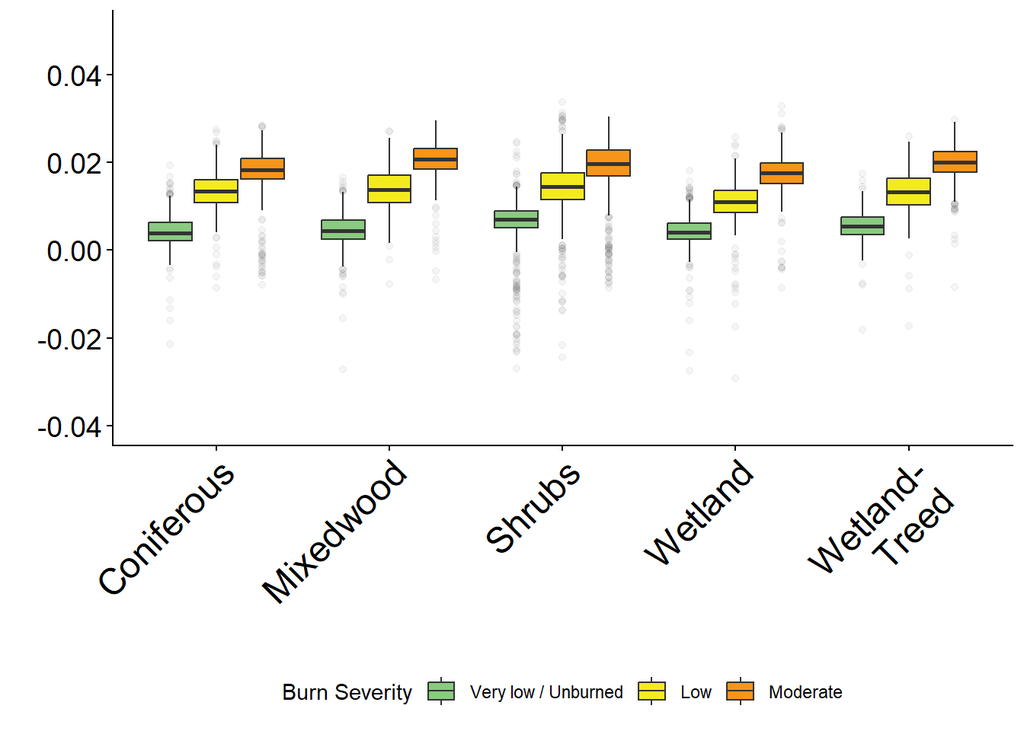

```r
# NDVI
ndvi_slope_plot <- ggplot(final_stats_ndvi,
       aes(x = LC_Name, y = NDVI_Slope, fill = Severity_Class)) +
  geom_boxplot(position = position_dodge(width = 0.8),
               outlier.alpha = 0.05) +
  scale_fill_manual(values = c("Very low / Unburned" = "#8aca81",
                               "Low" = "#f4eb1f",
                               "Moderate" = "#f69519"),
                    name = "Burn Severity") +
  scale_x_discrete(labels = c("Wetland-Treed" = "Wetland-\nTreed")) +
  scale_y_continuous(breaks = seq(-0.04, 0.06, by = 0.02)) +
  coord_cartesian(ylim = c(-0.04, 0.05)) +
  labs(x = " ", y = " ", fill = "Burn severity") +
  theme_classic() +
  theme(legend.position = "bottom", axis.text = element_text(size = 11),
        axis.text.x = element_text(size = 18, angle = 45, vjust = 1, hjust = 1),
        axis.text.y = element_text(size = 14))
ndvi_slope_plot
```

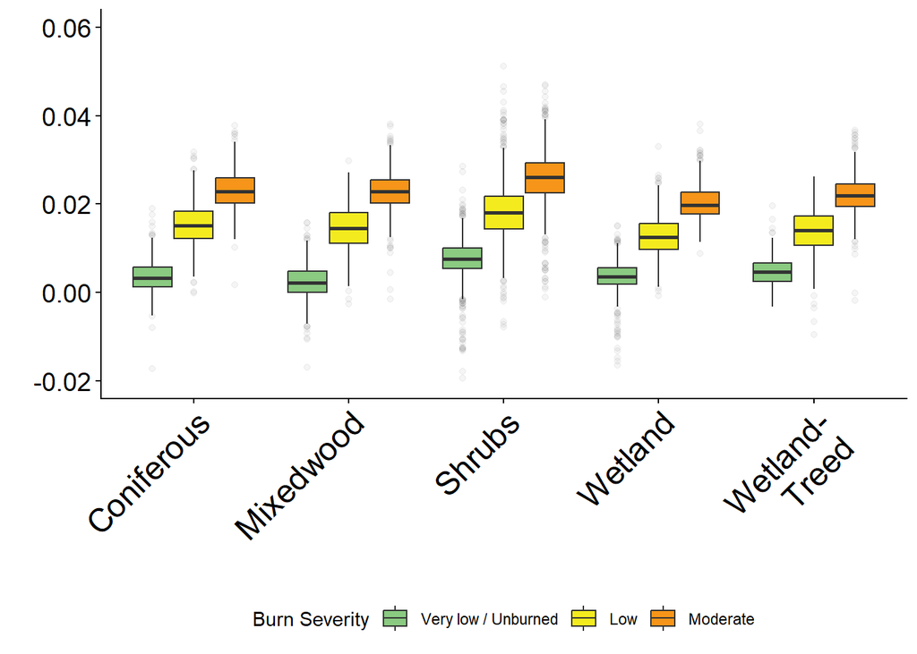

```r
## Using ggsave()
ggsave(filename = "plots/ndvi_slope_plot.png", ndvi_slope_plot,
       height = 6, width = 8, units = "in", dpi = 300)

# NBR
nbr_slope_plot <- ggplot(final_stats_nbr,
       aes(x = LC_Name, y = NBR_Slope, fill = Severity_Class)) +
  geom_boxplot(position = position_dodge(width = 0.8),
               outlier.alpha = 0.05) +
  scale_fill_manual(values = c("Very low / Unburned" = "#8aca81",
                               "Low" = "#f4eb1f",
                               "Moderate" = "#f69519"),
                    name = "Burn Severity") +
  scale_x_discrete(labels = c("Wetland-Treed" = "Wetland-\nTreed")) +
  scale_y_continuous(breaks = seq(-0.04, 0.06, by = 0.02)) +
  coord_cartesian(ylim = c(-0.02, 0.06)) +
  labs(x = " ", y = " ", fill = "Burn severity") +
  theme_classic() +
  theme(legend.position = "bottom", axis.text = element_text(size = 11),
        axis.text.x = element_text(size = 18, angle = 45, vjust = 1, hjust = 1),
        axis.text.y = element_text(size = 14))
nbr_slope_plot
```

```r
## Using ggsave()
ggsave(filename = "plots/nbr_slope_plot.png", nbr_slope_plot,
       height = 6, width = 8, units = "in", dpi = 300)
```

```r
# Q1 — Severity effect:
# Do recovery rates (NDVI_Slope / NBR_Slope) differ among burn severity classes?
# H0: Mean recovery slopes do not differ among severity classes.
# H1: At least one severity class differs in mean recovery slope.

# One-way ANOVA: Severity effect
# NDVI
anova_ndvi_sev <- aov(NDVI_Slope ~ Severity_Class, data = final_stats_ndvi)
summary(anova_ndvi_sev)
```

```
##                   Df Sum Sq Mean Sq F value Pr(>F)
## Severity_Class     2 0.4945 0.24723   12286 <2e-16 ***
## Residuals      14997 0.3018 0.00002
## ---
## Signif. codes:  0 '***' 0.001 '**' 0.01 '*' 0.05 '.' 0.1 ' ' 1
```

```r
tukey_ndvi_sev <- TukeyHSD(anova_ndvi_sev)
tukey_ndvi_sev
```

```
##   Tukey multiple comparisons of means
##     95% family-wise confidence level
##
## Fit: aov(formula = NDVI_Slope ~ Severity_Class, data = final_stats_ndvi)
##
## $Severity_Class
##                                     diff        lwr         upr p adj
## Low-Very low / Unburned      0.008189863 0.00797957 0.008400156     0
## Moderate-Very low / Unburned 0.013996026 0.01378573 0.014206319     0
## Moderate-Low                 0.005806163 0.00559587 0.006016456     0
```

```r
# NBR
anova_nbr_sev <- aov(NBR_Slope ~ Severity_Class, data = final_stats_nbr)
summary(anova_nbr_sev)
```

```
##                   Df Sum Sq Mean Sq F value Pr(>F)
## Severity_Class     2 0.8554  0.4277   18207 <2e-16 ***
## Residuals      14997 0.3523  0.0000
## ---
## Signif. codes:  0 '***' 0.001 '**' 0.01 '*' 0.05 '.' 0.1 ' ' 1
```

```r
tukey_nbr_sev <- TukeyHSD(anova_nbr_sev)
tukey_nbr_sev
```

```
##   Tukey multiple comparisons of means
##     95% family-wise confidence level
##
## Fit: aov(formula = NBR_Slope ~ Severity_Class, data = final_stats_nbr)
##
## $Severity_Class
##                                     diff         lwr         upr p adj
## Low-Very low / Unburned      0.010578867 0.010351654 0.010806080     0
## Moderate-Very low / Unburned 0.018430712 0.018203498 0.018657925     0
## Moderate-Low                 0.007851845 0.007624632 0.008079058     0
```

```r
# Q2 — Land cover effect:
# Do recovery rates differ among pre-fire land cover classes?
# H0: Mean recovery slopes do not differ among land cover classes.
# H1: At least one land cover class differs in mean recovery slope.

# One-way ANOVA: Land cover effect
# NDVI
anova_ndvi_lc <- aov(NDVI_Slope ~ LC_Name, data = final_stats_ndvi)
summary(anova_ndvi_lc)
```

```
##                Df Sum Sq   Mean Sq F value Pr(>F)
## LC_Name         4 0.0108 0.0026957   51.46 <2e-16 ***
## Residuals   14995 0.7855 0.0000524
## ---
## Signif. codes:  0 '***' 0.001 '**' 0.01 '*' 0.05 '.' 0.1 ' ' 1
```

```r
tukey_ndvi_lc <- TukeyHSD(anova_ndvi_lc)
tukey_ndvi_lc
```

```
##   Tukey multiple comparisons of means
##     95% family-wise confidence level
##
## Fit: aov(formula = NDVI_Slope ~ LC_Name, data = final_stats_ndvi)
##
## $LC_Name
##                                   diff           lwr           upr     p adj
## Mixedwood-Coniferous      1.048896e-03  0.0005390895  0.0015587021 0.0000002
## Shrubs-Coniferous         1.274860e-03  0.0007650541  0.0017846668 0.0000000
## Wetland-Coniferous       -9.752118e-04 -0.0014850181 -0.0004654054 0.0000018
## Wetland-Treed-Coniferous  1.019436e-03  0.0005096296  0.0015292423 0.0000005
## Shrubs-Mixedwood          2.259647e-04 -0.0002838417  0.0007357710 0.7460739
## Wetland-Mixedwood        -2.024108e-03 -0.0025339139 -0.0015143012 0.0000000
## Wetland-Treed-Mixedwood  -2.945987e-05 -0.0005392662  0.0004803465 0.9998617
## Wetland-Shrubs           -2.250072e-03 -0.0027598786 -0.0017402659 0.0000000
## Wetland-Treed-Shrubs     -2.554246e-04 -0.0007652309  0.0002543818 0.6490125
## Wetland-Treed-Wetland     1.994648e-03  0.0014848413  0.0025044540 0.0000000
```

```r
# NBR
anova_nbr_lc <- aov(NBR_Slope ~ LC_Name, data = final_stats_nbr)
summary(anova_nbr_lc)
```

```
##                Df Sum Sq  Mean Sq F value Pr(>F)
## LC_Name         4 0.0433 0.010830   139.5 <2e-16 ***
## Residuals   14995 1.1644 0.000078
## ---
## Signif. codes:  0 '***' 0.001 '**' 0.01 '*' 0.05 '.' 0.1 ' ' 1
```

```r
tukey_nbr_lc <- TukeyHSD(anova_nbr_lc)
tukey_nbr_lc
```

```
##   Tukey multiple comparisons of means
##     95% family-wise confidence level
##
## Fit: aov(formula = NBR_Slope ~ LC_Name, data = final_stats_nbr)
##
## $LC_Name
##                                   diff           lwr           upr     p adj
## Mixedwood-Coniferous     -0.0007884344 -0.0014091548 -0.0001677141 0.0048262
## Shrubs-Coniferous         0.0031998588  0.0025791385  0.0038205792 0.0000000
## Wetland-Coniferous       -0.0018272831 -0.0024480035 -0.0012065627 0.0000000
## Wetland-Treed-Coniferous -0.0004915101 -0.0011122305  0.0001292103 0.1950372
## Shrubs-Mixedwood          0.0039882932  0.0033675729  0.0046090136 0.0000000
## Wetland-Mixedwood        -0.0010388487 -0.0016595690 -0.0004181283 0.0000493
## Wetland-Treed-Mixedwood   0.0002969243 -0.0003237960  0.0009176447 0.6881201
## Wetland-Shrubs           -0.0050271419 -0.0056478623 -0.0044064216 0.0000000
## Wetland-Treed-Shrubs     -0.0036913689 -0.0043120893 -0.0030706486 0.0000000
## Wetland-Treed-Wetland     0.0013357730  0.0007150526  0.0019564934 0.0000001
```

```r
# Q3 — Interaction:
# Does the severity–recovery relationship change depending on land cover type?
# H0: No interaction (severity effect is the same across land cover classes).
# H1: There is an interaction (severity effect differs by land cover).

# Two-way ANOVA: Land cover × severity interaction

# NDVI
anova_ndvi_int <- aov(NDVI_Slope ~ LC_Name * Severity_Class, data = final_stats_ndvi)
summary(anova_ndvi_int)
```

```
##                           Df Sum Sq Mean Sq  F value Pr(>F)
## LC_Name                    4 0.0108 0.00270   141.12 <2e-16 ***
## Severity_Class             2 0.4945 0.24723 12942.69 <2e-16 ***
## LC_Name:Severity_Class     8 0.0048 0.00060    31.19 <2e-16 ***
## Residuals              14985 0.2862 0.00002
## ---
## Signif. codes:  0 '***' 0.001 '**' 0.01 '*' 0.05 '.' 0.1 ' ' 1
```

```r
tukey_ndvi_int <- TukeyHSD(anova_ndvi_int)
tukey_ndvi_int
```

```
##   Tukey multiple comparisons of means
##     95% family-wise confidence level
##
## Fit: aov(formula = NDVI_Slope ~ LC_Name * Severity_Class, data = final_stats_ndvi)
##
## $LC_Name
##                                   diff           lwr           upr     p adj
## Mixedwood-Coniferous      1.048896e-03  7.410363e-04  1.356755e-03 0.0000000
## Shrubs-Coniferous         1.274860e-03  9.670009e-04  1.582720e-03 0.0000000
## Wetland-Coniferous       -9.752118e-04 -1.283071e-03 -6.673522e-04 0.0000000
## Wetland-Treed-Coniferous  1.019436e-03  7.115764e-04  1.327295e-03 0.0000000
## Shrubs-Mixedwood          2.259647e-04 -8.189485e-05  5.338242e-04 0.2647775
## Wetland-Mixedwood        -2.024108e-03 -2.331967e-03 -1.716248e-03 0.0000000
## Wetland-Treed-Mixedwood  -2.945987e-05 -3.373194e-04  2.783997e-04 0.9989804
## Wetland-Shrubs           -2.250072e-03 -2.557932e-03 -1.942213e-03 0.0000000
## Wetland-Treed-Shrubs     -2.554246e-04 -5.632841e-04  5.243497e-05 0.1569313
## Wetland-Treed-Wetland     1.994648e-03  1.686788e-03  2.302507e-03 0.0000000
##
## $Severity_Class
##                                     diff         lwr         upr p adj
## Low-Very low / Unburned      0.008189863 0.007984977 0.008394749     0
## Moderate-Very low / Unburned 0.013996026 0.013791140 0.014200912     0
## Moderate-Low                 0.005806163 0.005601277 0.006011049     0
##
## $`LC_Name:Severity_Class`
##                                                                           diff
## Mixedwood:Very low / Unburned-Coniferous:Very low / Unburned      3.272342e-04
## Shrubs:Very low / Unburned-Coniferous:Very low / Unburned         2.068864e-03
## Wetland:Very low / Unburned-Coniferous:Very low / Unburned        1.894461e-05
## Wetland-Treed:Very low / Unburned-Coniferous:Very low / Unburned  1.306219e-03
## Coniferous:Low-Coniferous:Very low / Unburned                     9.171883e-03
## Mixedwood:Low-Coniferous:Very low / Unburned                      9.610064e-03
## Shrubs:Low-Coniferous:Very low / Unburned                         9.986100e-03
## Wetland:Low-Coniferous:Very low / Unburned                        6.789227e-03
## Wetland-Treed:Low-Coniferous:Very low / Unburned                  9.113302e-03
## Coniferous:Moderate-Coniferous:Very low / Unburned                1.382597e-02
## Mixedwood:Moderate-Coniferous:Very low / Unburned                 1.620725e-02
## Shrubs:Moderate-Coniferous:Very low / Unburned                    1.476748e-02
## Wetland:Moderate-Coniferous:Very low / Unburned                   1.326405e-02
## Wetland-Treed:Moderate-Coniferous:Very low / Unburned             1.563664e-02
```

[output cut: 394 more lines]

```
## Coniferous:Moderate-Wetland-Treed:Low                            0.0000000
## Mixedwood:Moderate-Wetland-Treed:Low                             0.0000000
## Shrubs:Moderate-Wetland-Treed:Low                                0.0000000
## Wetland:Moderate-Wetland-Treed:Low                               0.0000000
## Wetland-Treed:Moderate-Wetland-Treed:Low                         0.0000000
## Mixedwood:Moderate-Coniferous:Moderate                           0.0000000
## Shrubs:Moderate-Coniferous:Moderate                              0.0001475
## Wetland:Moderate-Coniferous:Moderate                             0.2080686
## Wetland-Treed:Moderate-Coniferous:Moderate                       0.0000000
## Shrubs:Moderate-Mixedwood:Moderate                               0.0000000
## Wetland:Moderate-Mixedwood:Moderate                              0.0000000
## Wetland-Treed:Moderate-Mixedwood:Moderate                        0.1872640
## Wetland:Moderate-Shrubs:Moderate                                 0.0000000
## Wetland-Treed:Moderate-Shrubs:Moderate                           0.0008463
## Wetland-Treed:Moderate-Wetland:Moderate                          0.0000000
```

```r
#NBR
anova_nbr_int <- aov(NBR_Slope ~ LC_Name * Severity_Class, data = final_stats_nbr)
summary(anova_nbr_int)
```

```
##                           Df Sum Sq Mean Sq  F value Pr(>F)
## LC_Name                    4 0.0433  0.0108   534.89 <2e-16 ***
## Severity_Class             2 0.8554  0.4277 21125.09 <2e-16 ***
## LC_Name:Severity_Class     8 0.0056  0.0007    34.52 <2e-16 ***
## Residuals              14985 0.3034  0.0000
## ---
## Signif. codes:  0 '***' 0.001 '**' 0.01 '*' 0.05 '.' 0.1 ' ' 1
```

```r
tukey_nbr_int <- TukeyHSD(anova_nbr_int)
tukey_nbr_int
```

```
##   Tukey multiple comparisons of means
##     95% family-wise confidence level
##
## Fit: aov(formula = NBR_Slope ~ LC_Name * Severity_Class, data = final_stats_nbr)
##
## $LC_Name
##                                   diff           lwr           upr     p adj
## Mixedwood-Coniferous     -0.0007884344 -1.105386e-03 -0.0004714832 0.0000000
## Shrubs-Coniferous         0.0031998588  2.882908e-03  0.0035168101 0.0000000
## Wetland-Coniferous       -0.0018272831 -2.144234e-03 -0.0015103319 0.0000000
## Wetland-Treed-Coniferous -0.0004915101 -8.084613e-04 -0.0001745589 0.0002272
## Shrubs-Mixedwood          0.0039882932  3.671342e-03  0.0043052445 0.0000000
## Wetland-Mixedwood        -0.0010388487 -1.355800e-03 -0.0007218975 0.0000000
## Wetland-Treed-Mixedwood   0.0002969243 -2.002691e-05  0.0006138755 0.0788347
## Wetland-Shrubs           -0.0050271419 -5.344093e-03 -0.0047101907 0.0000000
## Wetland-Treed-Shrubs     -0.0036913689 -4.008320e-03 -0.0033744177 0.0000000
## Wetland-Treed-Wetland     0.0013357730  1.018822e-03  0.0016527242 0.0000000
##
## $Severity_Class
##                                     diff         lwr         upr p adj
## Low-Very low / Unburned      0.010578867 0.010367930 0.010789803     0
## Moderate-Very low / Unburned 0.018430712 0.018219775 0.018641648     0
## Moderate-Low                 0.007851845 0.007640908 0.008062781     0
##
## $`LC_Name:Severity_Class`
##                                                                           diff
## Mixedwood:Very low / Unburned-Coniferous:Very low / Unburned     -1.228079e-03
## Shrubs:Very low / Unburned-Coniferous:Very low / Unburned         3.803722e-03
## Wetland:Very low / Unburned-Coniferous:Very low / Unburned       -8.869307e-06
## Wetland-Treed:Very low / Unburned-Coniferous:Very low / Unburned  9.630254e-04
## Coniferous:Low-Coniferous:Very low / Unburned                     1.169178e-02
## Mixedwood:Low-Coniferous:Very low / Unburned                      1.081278e-02
## Shrubs:Low-Coniferous:Very low / Unburned                         1.454726e-02
## Wetland:Low-Coniferous:Very low / Unburned                        9.018215e-03
## Wetland-Treed:Low-Coniferous:Very low / Unburned                  1.035409e-02
## Coniferous:Moderate-Coniferous:Very low / Unburned                1.938009e-02
## Mixedwood:Moderate-Coniferous:Very low / Unburned                 1.912187e-02
## Shrubs:Moderate-Coniferous:Very low / Unburned                    2.232047e-02
## Wetland:Moderate-Coniferous:Very low / Unburned                   1.658068e-02
## Wetland-Treed:Moderate-Coniferous:Very low / Unburned             1.828023e-02
```

[output cut: 394 more lines]

```
## Coniferous:Moderate-Wetland-Treed:Low                            0.0000000
## Mixedwood:Moderate-Wetland-Treed:Low                             0.0000000
## Shrubs:Moderate-Wetland-Treed:Low                                0.0000000
## Wetland:Moderate-Wetland-Treed:Low                               0.0000000
## Wetland-Treed:Moderate-Wetland-Treed:Low                         0.0000000
## Mixedwood:Moderate-Coniferous:Moderate                           0.9946569
## Shrubs:Moderate-Coniferous:Moderate                              0.0000000
## Wetland:Moderate-Coniferous:Moderate                             0.0000000
## Wetland-Treed:Moderate-Coniferous:Moderate                       0.0000049
## Shrubs:Moderate-Mixedwood:Moderate                               0.0000000
## Wetland:Moderate-Mixedwood:Moderate                              0.0000000
## Wetland-Treed:Moderate-Mixedwood:Moderate                        0.0026802
## Wetland:Moderate-Shrubs:Moderate                                 0.0000000
## Wetland-Treed:Moderate-Shrubs:Moderate                           0.0000000
## Wetland-Treed:Moderate-Wetland:Moderate                          0.0000000
```

### Severity Distribution

**Severity Distribution**

This section checks how dNBR values are distributed across the fire area.

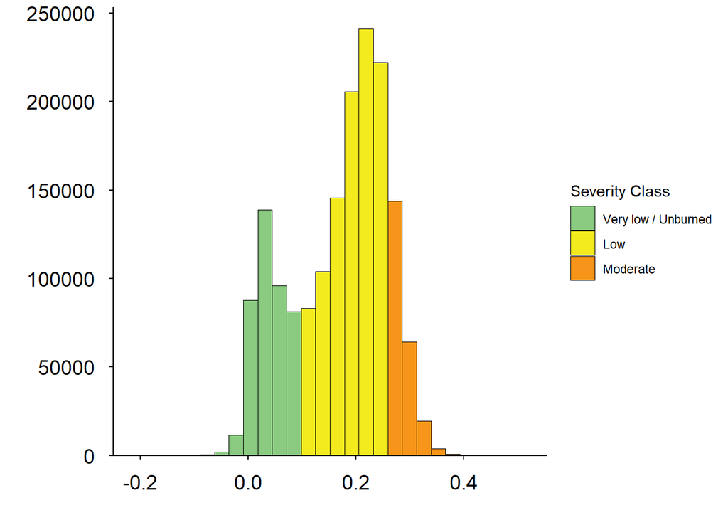

```r
# plot
sev_dist <- ggplot(combined_table, aes(x = dNBR_raw)) +
  geom_histogram(aes(
    fill = after_stat(cut(x,
                          breaks = c(-Inf, 0.1, 0.27, Inf),
                          labels = c("Very low / Unburned", "Low", "Moderate")))),
    color = "black", linewidth = 0.2) +
  scale_fill_manual(values = c("Very low / Unburned" = "#8aca81",
                               "Low" = "#f4eb1f",
                               "Moderate" = "#f69519"),
                    name = "Severity Class") +
  scale_x_continuous(expand = expansion(mult = 0)) +
  scale_y_continuous(expand = expansion(mult = c(0, 0.05))) +
  labs(x = " ", y = " ") +
  theme_classic() +
  theme(axis.text = element_text(size = 14),
        axis.text.y = element_text(margin = margin(r = 10)),
        axis.text.x = element_text(margin = margin(t = 10)))
sev_dist
```

```r
## Using ggsave()
ggsave(filename = "plots/severity_distribution.png", sev_dist,
       height = 4, width = 8, units = "in", dpi = 300)
```

### Recovery Barplots

**Recovery Plots**

Bar charts showing the percent of pixels by years-to-recovery (NDVI and NBR) with “NR” for not recovered.

*NDVI*

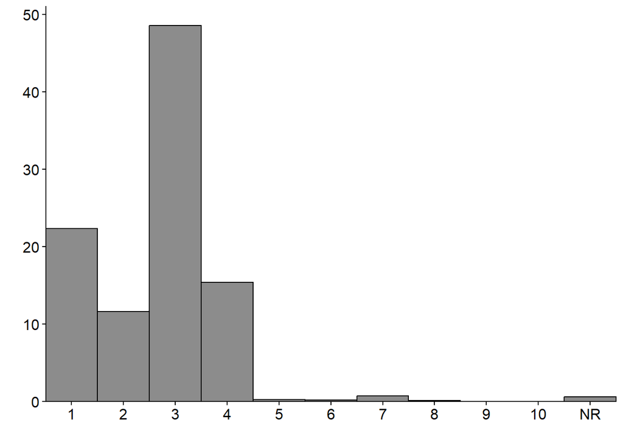

```r
# prep plot table from the combined table that was vegetation filtered
df_plot_y2r_ndvi <- stats_ndvi %>%
  group_by(NDVI_recovery_year) %>%
  summarise(count = n()) %>%
  mutate(years_to_recover = ifelse(NDVI_recovery_year == 0, "NR",
                                   (NDVI_recovery_year - 2013)),
         perc_recovered   = count / sum(count) * 100)

# plot NDVI recovery distribution
plot_y2r_ndvi <- ggplot(df_plot_y2r_ndvi,
       aes(x = factor(years_to_recover,
                      levels = c(as.character(1:11), "NR")),
           y = perc_recovered)) +
  geom_col(fill = "grey55", color = "black", width = 1) +
  scale_y_continuous(limits = c(0, 50),
                     breaks = seq(0, 50, by = 5),
                     labels = c("0","","10","","20","","30","","40","","50")) +
  labs(x = "", y = "") +
  theme_classic() +
  theme(axis.text = element_text(size = 12)) +
  scale_x_discrete(expand = c(0, 0)) +
  scale_y_continuous(expand = c(0, 0),limits = c(0, 51))
plot_y2r_ndvi
```

```r
## Using ggsave()
ggsave(filename = "plots/plot_y2r_ndvi.png", plot_y2r_ndvi,
       height = 4, width = 8, units = "in", dpi = 300)
```

*NBR*

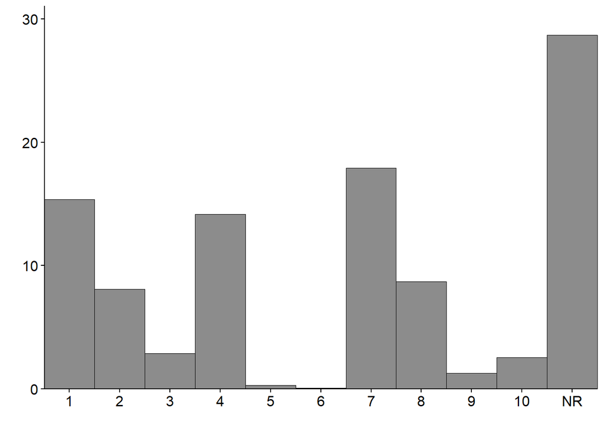

```r
# prep plot table from the combined table that was vegetation filtered
df_plot_y2r_nbr <- stats_nbr %>%
  group_by(NBR_recovery_year) %>%
  summarise(count = n()) %>%
  mutate(years_to_recover = ifelse(NBR_recovery_year == 0, "NR",
                                   (NBR_recovery_year - 2013)),
         perc_recovered   = count / sum(count) * 100)

# plot NBR recovery distribution
plot_y2r_nbr <- ggplot(df_plot_y2r_nbr,
       aes(x = factor(years_to_recover,
                      levels = c(as.character(1:11), "NR")),
           y = perc_recovered)) +
  geom_col(fill = "grey55", color = "black", width = 1, linewidth = 0.2) +
  scale_y_continuous(limits = c(0, 30),
                     breaks = seq(0, 30, by = 5),
                     labels = c("0","","10","","20","","30")) +
  labs(x = "", y = "") +     # add labels
  theme_classic() +
  theme(axis.text = element_text(size = 12)) +
  scale_x_discrete(expand = c(0, 0)) +
  scale_y_continuous(expand = c(0, 0),limits = c(0, 31))
plot_y2r_nbr
```

```r
## Using ggsave()
ggsave(filename = "plots/plot_y2r_nbr.png", plot_y2r_nbr,
       height = 4, width = 8, units = "in", dpi = 300)
```

### Land cover Analysis

**Land cover Analysis**

This section summarizes how land cover changes through time after the 2013 fire, and compares burn severity (dNBR) ranges across the main vegetation classes.

**Land Cover Persistence**

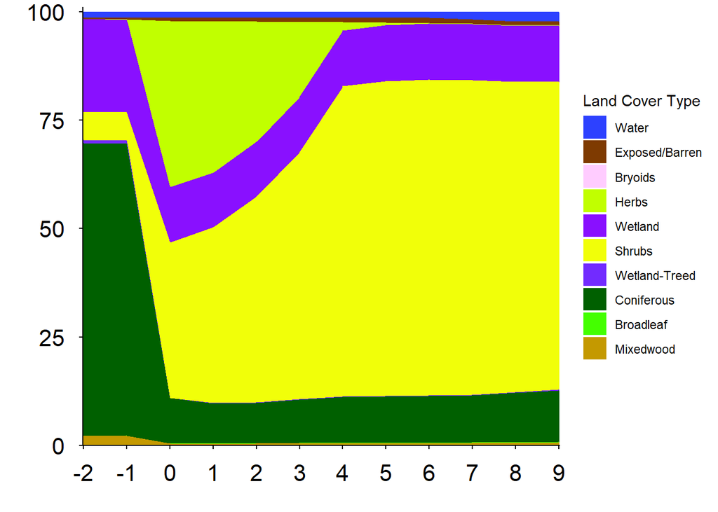

```r
lc_stats_yearly <- as.data.frame(lc_stack) %>%
  pivot_longer(cols = everything(),
               names_to = "Year_Raw",
               values_to = "land_cover_ID") %>%
  mutate(Calendar_Year = as.integer(gsub("LC_", "", Year_Raw)),
         Years_Since_Fire = Calendar_Year - 2013) %>%
  group_by(Years_Since_Fire, land_cover_ID) %>%
  summarise(Count = n()) %>%
  group_by(Years_Since_Fire) %>%
  mutate(Percentage = (Count / sum(Count)) * 100) %>%
  left_join(land_cover_lookup, by = "land_cover_ID")

#
lc_stats_yearly$LC_Name <- factor(lc_stats_yearly$LC_Name,
                                 levels = c("Water", "Snow/Ice", "Rock/Rubble",
                                            "Exposed/Barren", "Bryoids", "Herbs",
                                            "Wetland", "Shrubs", "Wetland-Treed",
                                            "Coniferous", "Broadleaf", "Mixedwood"))

lc_persistence <- ggplot(lc_stats_yearly,
       aes(x = Years_Since_Fire, y = Percentage, fill = LC_Name)) +
  geom_area() +
  scale_x_continuous(expand = expansion(mult = 0),
                     breaks = c(-2,-1,0,1,2,3,4,5,6,7,8,9)) +
  scale_y_continuous(expand = expansion(mult = c(0, 0.01))) +
  scale_fill_manual(values = c(
    "Water"           = "#2d41ff",
    "Snow/Ice"        = "#e0ffff",
    "Rock/Rubble"     = "#cccccc",
    "Exposed/Barren"  = "#7e3a01",
    "Bryoids"         = "#ffccff",
    "Herbs"           = "#c1ff00",
    "Wetland"         = "#8910ff",
    "Shrubs"          = "#f1ff09",
    "Wetland-Treed"   = "#722bff",
    "Coniferous"      = "#006000",
    "Broadleaf"       = "#44ff00",
    "Mixedwood"       = "#c49900"
  )) +
  labs(x = " ",
       y = " ",
       fill = "Land Cover Type") +
  theme_classic() +
  theme(axis.text = element_text(size = 16)) +
  theme(axis.text.y = element_text(margin = margin(r = 10)),
        axis.text.x = element_text(margin = margin(t = 10)))
lc_persistence
```

```r
ggsave("plots/lc_persistence.tif", plot = lc_persistence)
ggsave("plots/lc_persistence.png", plot = lc_persistence, width = 12, height = 8, dpi = 300)
```

**Land cover - severity ranges**

```r
# calculate min and max
dnbr_min <- zonal(dnbr_raw, lc_2012, fun = "min", na.rm = TRUE)
dnbr_max <- zonal(dnbr_raw, lc_2012, fun = "max", na.rm = TRUE)

# rename columns
colnames(dnbr_min) <- c("land_cover_ID", "min_dnbr")
colnames(dnbr_max) <- c("land_cover_ID", "max_dnbr")

# create the final table
dnbr_table <- left_join(dnbr_min, dnbr_max, by = "land_cover_ID") %>%
  mutate(range_dnbr = max_dnbr - min_dnbr) %>%  # create range from min and max
  left_join(land_cover_lookup, by = "land_cover_ID")

# filter certain land cover types
dnbr_table_final <- dnbr_table %>%
  filter(LC_Name %in% c("Coniferous", "Mixedwood", "Shrubs",
                        "Wetland", "Wetland-Treed"))
print(dnbr_table_final)
```

```
##   land_cover_ID    min_dnbr  max_dnbr range_dnbr       LC_Name
## 1            50 -0.09938379 0.4038491  0.5032328        Shrubs
## 2            80 -0.23609886 0.4163461  0.6524449       Wetland
## 3            81 -0.06977937 0.4003952  0.4701746 Wetland-Treed
## 4           210 -0.15281264 0.4015138  0.5543264    Coniferous
## 5           230 -0.08010103 0.4289086  0.5090096     Mixedwood
```